# Homework 2

##Data Wrangling

```r
# Download Two datasets
download.file("https://raw.githubusercontent.com/USCbiostats/data-science-data/master/01_chs/chs_individual.csv", "chs_individual.csv", method="libcurl", timeout = 60)
ind <- data.table::fread("chs_individual.csv")

download.file("https://raw.githubusercontent.com/USCbiostats/data-science-data/master/01_chs/chs_regional.csv", "chs_regional.csv", method="libcurl", timeout = 60)
reg <- data.table::fread("chs_regional.csv")
```

```r
dim(ind)
```

```
## [1] 1200   23
```

```r
dim(reg)
```

```
## [1] 12 27
```

There are 1200 observations and 23 variables in the individual dataset and there are 12 observations and 27 variables in the regional dataset.

##1. After merging the data, make sure you don’t have any duplicates by counting the number of rows. Make sure it matches.

```r
# Dealing with NAs and 999999
ind <- fread("https://raw.githubusercontent.com/USCbiostats/data-science-data/master/01_chs/chs_individual.csv")
ind [, sid := as.integer(sid)]
ind [, sid   := fifelse( sid == 999999, NA_integer_, sid)]
ind [, townname   := fifelse(townname == "", NA_character_, townname)]
ind [, race  := fifelse(race == "", NA_character_, race)]

# Selecting the three relevant columns, and keeping unique records
ind <- unique(ind [, list( townname, bmi, sid,smoke, gasstove, fev, asthma,male )])

# Dropping NAs
ind <- ind [!is.na(sid)]

# Removing duplicates
ind [, n := 1:.N, by = .(sid)]
ind <- ind [n == 1,][, n := NULL]

loc <- merge(x = ind, y = reg, by.x = "townname", by.y="townname", all.x = TRUE, all.y = FALSE)
merge(x = ind, y = reg, by.x = "townname", by.y = "townname", all.x = TRUE, all.y = FALSE) %>%nrow()
```

```
## [1] 1200
```

The observations we got is remaining the same, so there is no dupilicates.

##2. Create a new categorical variable named “obesity_level” using the BMI measurement (underweight BMI<14; normal BMI 14-22; overweight BMI 22-24; obese BMI>24). To make sure the variable is rightly coded, create a summary table that contains the minimum BMI, maximum BMI, and the total number of observations per category.

```r
loc [bmi<14, obesity_level := "underweight"]
loc [bmi>=14 & bmi<22, obesity_level := "normal"]
loc [bmi>=22 & bmi<24, obesity_level := "overweight"]
loc [bmi>=24, obesity_level := "obese"]
loc[,.(bmi_min = min(bmi, na.rm=TRUE),
       bmi_max = max(bmi, na.rm=TRUE), n= length(bmi)),by =  obesity_level] [order(obesity_level)]
```

```
##    obesity_level  bmi_min  bmi_max   n
## 1:        normal 14.00380 21.96387 886
## 2:         obese 24.00647 41.26613 103
## 3:    overweight 22.02353 23.99650  87
## 4:   underweight 11.29640 13.98601  35
## 5:          <NA>      Inf     -Inf  89
```

##3. Create another categorical variable named “smoke_gas_exposure” that summarizes “Second Hand Smoke” and “Gas Stove.” The variable should have four categories in total.

```r
loc[smoke==0 & gasstove ==0, smoke_gas_exposure := "No exposure"]
loc[smoke==1 & gasstove ==0, smoke_gas_exposure := "Smoke exposure only"]
loc[smoke==0 & gasstove ==1, smoke_gas_exposure := "Gasstove exposure only"]
loc[smoke==1 & gasstove ==1, smoke_gas_exposure := "Exposure for both"]
loc[,.(n= length(smoke)), by = smoke_gas_exposure][order(smoke_gas_exposure)]
```

```
##        smoke_gas_exposure   n
## 1:      Exposure for both 151
## 2: Gasstove exposure only 739
## 3:            No exposure 214
## 4:    Smoke exposure only  36
## 5:                   <NA>  60
```

##4. Create four summary tables showing the average (or proportion, if binary) and sd of “Forced expiratory volume in 1 second (ml)” and asthma indicator by town, sex, obesity level, and “smoke_gas_exposure.”

```r
loc[,.(
   fev_mean = mean(fev, na.rm=TRUE),

   fev_sd = sd(fev, na.rm=TRUE),
   asthma_prop = mean(asthma, na.rm=TRUE),
   asthma_sd = sd(asthma,na.rm=TRUE)), by = townname][order(townname)]
```

```
##          townname fev_mean   fev_sd asthma_prop asthma_sd
##  1:        Alpine 2089.014 298.2039   0.1134021 0.3187308
##  2:    Atascadero 2079.374 331.8782   0.2551020 0.4381598
##  3: Lake Elsinore 2039.787 317.6112   0.1263158 0.3339673
##  4:  Lake Gregory 2091.665 337.8286   0.1515152 0.3603750
##  5:     Lancaster 2002.550 337.1053   0.1649485 0.3730620
##  6:        Lompoc 2038.227 367.4474   0.1134021 0.3187308
##  7:    Long Beach 1983.896 330.6271   0.1354167 0.3439642
##  8:     Mira Loma 1984.726 336.6416   0.1578947 0.3665767
##  9:     Riverside 1986.212 289.7415   0.1100000 0.3144660
## 10:     San Dimas 2027.806 321.9740   0.1717172 0.3790537
## 11:   Santa Maria 2022.553 330.0457   0.1340206 0.3424442
## 12:        Upland 2027.284 357.2010   0.1212121 0.3280346
```

```r
loc[,.(
   fev_mean = mean(fev, na.rm=TRUE),
   fev_sd = sd(fev, na.rm=TRUE),
   asthma_prop = mean(asthma, na.rm=TRUE),
   asthma_sd = sd(asthma,na.rm=TRUE)), by = male][order(male)]
```

```
##    male fev_mean   fev_sd asthma_prop asthma_sd
## 1:    0 1959.105 327.2948   0.1208054 0.3261747
## 2:    1 2103.819 318.2036   0.1727749 0.3783828
```

```r
loc[,.(
   fev_mean = mean(fev, na.rm=TRUE),
   fev_sd = sd(fev, na.rm=TRUE),
   asthma_prop = mean(asthma, na.rm=TRUE),
   asthma_sd = sd(asthma,na.rm=TRUE)), by = obesity_level][order(obesity_level)]
```

```
##    obesity_level fev_mean   fev_sd asthma_prop asthma_sd
## 1:        normal 1997.974 309.4085  0.14104046 0.3482647
## 2:         obese 2269.295 325.5054  0.21000000 0.4093602
## 3:    overweight 2224.322 317.4261  0.16470588 0.3731162
## 4:   underweight 1686.800 300.0803  0.08571429 0.2840286
## 5:          <NA>      NaN       NA  0.13095238 0.3393744
```

```r
loc[,.(
   fev_mean = mean(fev, na.rm=TRUE),
   fev_sd = sd(fev, na.rm=TRUE),
   asthma_prop = mean(asthma, na.rm=TRUE),
   asthma_sd = sd(asthma,na.rm=TRUE)), by = smoke_gas_exposure][order(smoke_gas_exposure)]
```

```
##        smoke_gas_exposure fev_mean   fev_sd asthma_prop asthma_sd
## 1:      Exposure for both 2019.974 313.2327   0.1301370 0.3376123
## 2: Gasstove exposure only 2026.308 328.1240   0.1477428 0.3550878
## 3:            No exposure 2059.943 342.5625   0.1476190 0.3555696
## 4:    Smoke exposure only 2064.346 333.2266   0.1714286 0.3823853
## 5:                   <NA> 1999.783 364.9553   0.1489362 0.3598746
```

## Looking at the Data (EDA)

```r
library(leaflet)
library(tidyverse)
library(ggplot2)
```

##1. Facet plot showing scatterplots with regression lines of BMI vs FEV by “townname”.

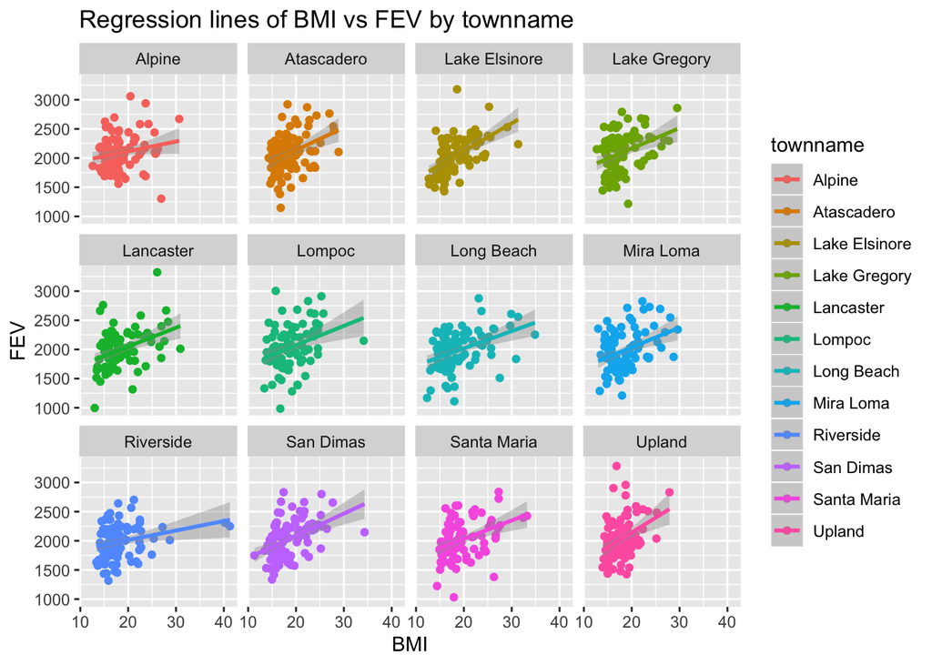

```r
loc %>%
  filter(!(townname %in% NA)) %>%
  ggplot(mapping = aes(x= bmi, y=fev, color=townname))+
  geom_point()+stat_smooth(method = lm)+ facet_wrap(~ townname)+
  labs(title="Regression lines of BMI vs FEV by townname", x="BMI",y="FEV")
```

From the scatterplots we got, we can tell that each city has a positive relation between BMI and FEV.

##2. Stacked histograms of FEV by BMI category and FEV by smoke/gas exposure. Use different color schemes than the ggplot default.

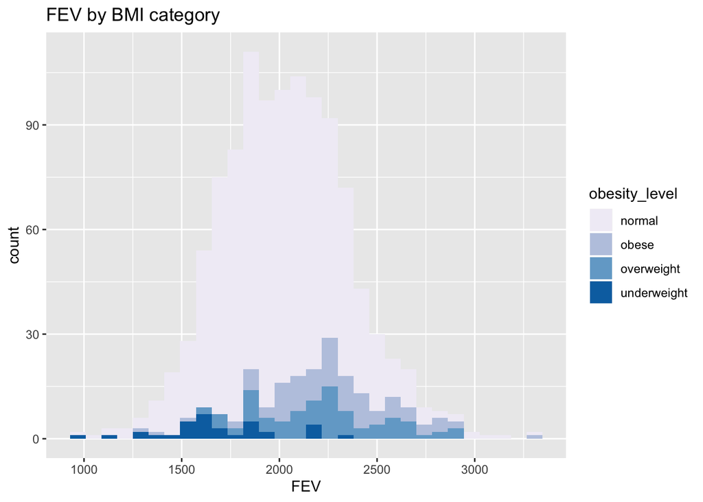

```r
loc %>%
  filter(!(obesity_level %in% NA)) %>%
  ggplot()+
  geom_histogram(mapping=aes(x=fev,fill=obesity_level))+
  scale_fill_brewer(palette = "PuBu")+
  labs(title="FEV by BMI category", x="FEV", y="count")
```

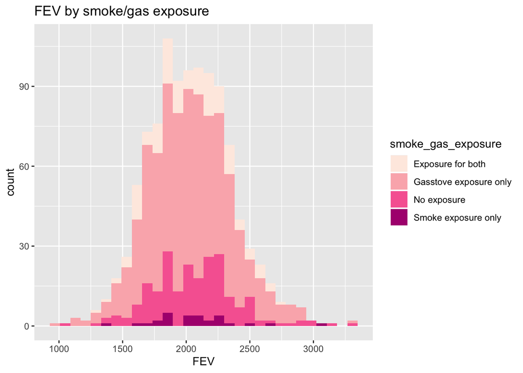

```r
loc %>%
  filter(!(smoke_gas_exposure %in% NA)) %>%
 ggplot()+
  geom_histogram(mapping=aes(x=fev,fill=smoke_gas_exposure))+
  scale_fill_brewer(palette = "RdPu")+
  labs(title="FEV by smoke/gas exposure", x="FEV", y="count")
```

##3. Barchart of BMI by smoke/gas exposure.

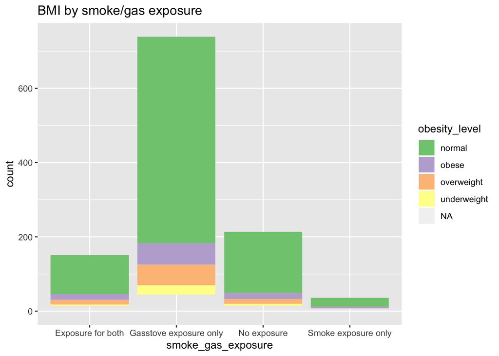

```r
loc %>%
  filter(!(smoke_gas_exposure %in% NA)) %>%
  ggplot()+
  geom_bar(mapping=aes(x=smoke_gas_exposure,fill=obesity_level))+
  scale_fill_brewer(palette = "Accent")+
  labs(title="BMI by smoke/gas exposure")
```

##4. Statistical summary graphs of FEV by BMI and FEV by smoke/gas exposure category.

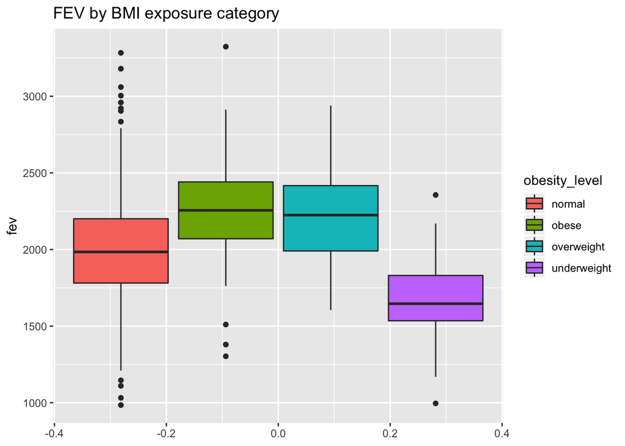

```r
loc %>%
ggplot() +
  geom_boxplot(mapping=aes(y=fev, fill=obesity_level))+
  labs(title = ("FEV by BMI exposure category"))
```

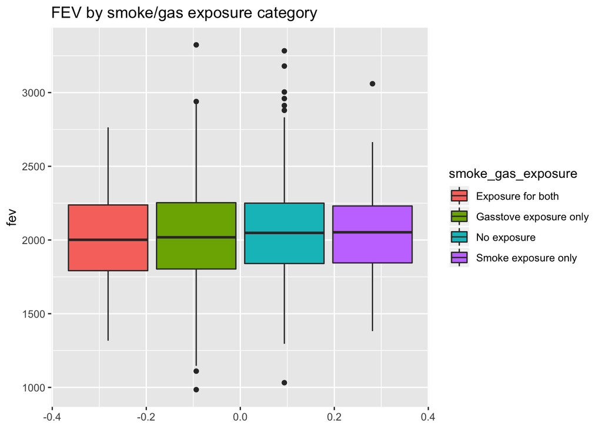

```r
loc %>%
    filter(!(smoke_gas_exposure %in% NA)) %>%
    ggplot() +
    geom_boxplot(mapping=aes(y=fev, fill=smoke_gas_exposure))+
    labs(title = ("FEV by smoke/gas exposure category"))
```

Compaing to the normal weight children, the overweight children have higher mean FEV, and underweight children have lower FEV. And the smoke and gas exposure seems have no influences on FEV.

##5. A leaflet map showing the concentrations of PM2.5 mass in each of the CHS communities.

```r
leaflet(loc) %>%
  addProviderTiles('OpenStreetMap') %>%
  addCircles(lat=~lat, lng=~lon, color="blue",opacity=1,
             fillOpacity=1, radius=~(pm25_mass*300))
```

[interactive chart not shown]

##6. Choose a visualization to examine whether PM2.5 mass is associated with FEV.

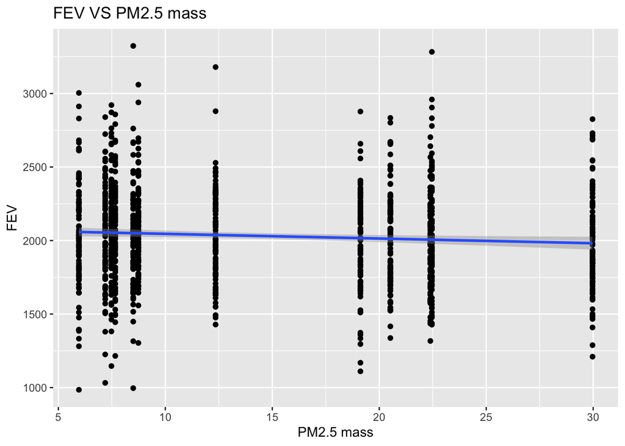

```r
loc %>%
  filter(!(pm25_mass %in% NA)) %>%
  ggplot(mapping = aes(x = pm25_mass, y = fev))+
  geom_point()+
  stat_smooth(method = lm)+
  labs(titles="FEV VS PM2.5 mass", x="PM2.5 mass", y="FEV")
```